# Final Project for QMSS Data Mining

Saad Khalid (sk3968), Adnan Hajizada (ah3326)

May 11, 2016

# Load Libraries

```r
# loading the required packages for the project
  library(ggplot2)
  library(dplyr)
  library(plyr)
  library(GGally)
  library(RColorBrewer)
  library(ggthemes)
  library(gridExtra)
#Read In the set
redWine <- read.csv('wineQualityReds.csv')
wineQuality <- read.csv("wineQualityReds.csv")
```

#### Dimensions of the data-set:

```
## [1] 1599   13
```

#### Names of the variables in the data-set:

```
##  [1] "X"                    "fixed.acidity"        "volatile.acidity"
##  [4] "citric.acid"          "residual.sugar"       "chlorides"
##  [7] "free.sulfur.dioxide"  "total.sulfur.dioxide" "density"
## [10] "pH"                   "sulphates"            "alcohol"
## [13] "quality"
```

#### Checking the data types of all the variables in the data-set:

```
## 'data.frame':    1599 obs. of  13 variables:
##  $ X                   : int  1 2 3 4 5 6 7 8 9 10 ...
##  $ fixed.acidity       : num  7.4 7.8 7.8 11.2 7.4 7.4 7.9 7.3 7.8 7.5 ...
##  $ volatile.acidity    : num  0.7 0.88 0.76 0.28 0.7 0.66 0.6 0.65 0.58 0.5 ...
##  $ citric.acid         : num  0 0 0.04 0.56 0 0 0.06 0 0.02 0.36 ...
##  $ residual.sugar      : num  1.9 2.6 2.3 1.9 1.9 1.8 1.6 1.2 2 6.1 ...
##  $ chlorides           : num  0.076 0.098 0.092 0.075 0.076 0.075 0.069 0.065 0.073 0.071 ...
##  $ free.sulfur.dioxide : num  11 25 15 17 11 13 15 15 9 17 ...
##  $ total.sulfur.dioxide: num  34 67 54 60 34 40 59 21 18 102 ...
##  $ density             : num  0.998 0.997 0.997 0.998 0.998 ...
##  $ pH                  : num  3.51 3.2 3.26 3.16 3.51 3.51 3.3 3.39 3.36 3.35 ...
##  $ sulphates           : num  0.56 0.68 0.65 0.58 0.56 0.56 0.46 0.47 0.57 0.8 ...
##  $ alcohol             : num  9.4 9.8 9.8 9.8 9.4 9.4 9.4 10 9.5 10.5 ...
##  $ quality             : int  5 5 5 6 5 5 5 7 7 5 ...
```

## histogram for quality values of wines

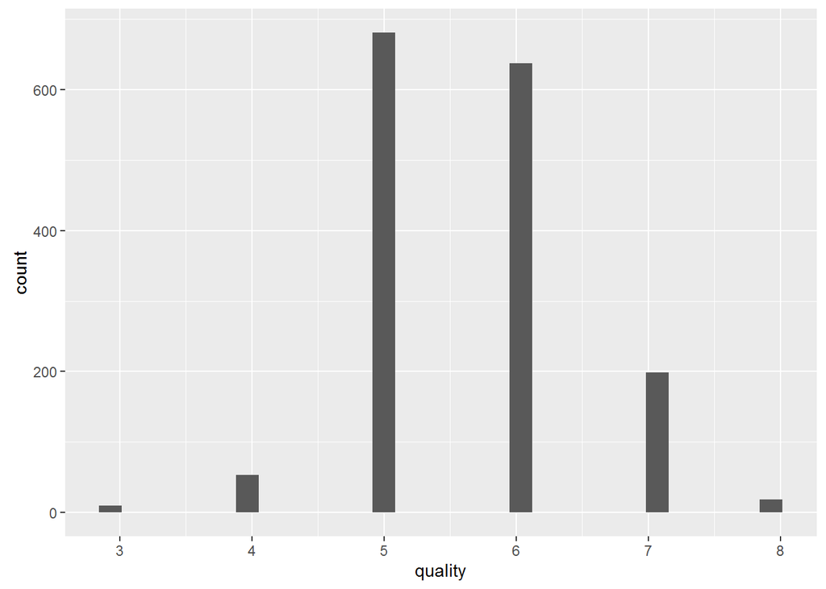

## What are the key variables that need to be investigated in the red wine dataset?

To aid in identification, we will make a plot matrix.

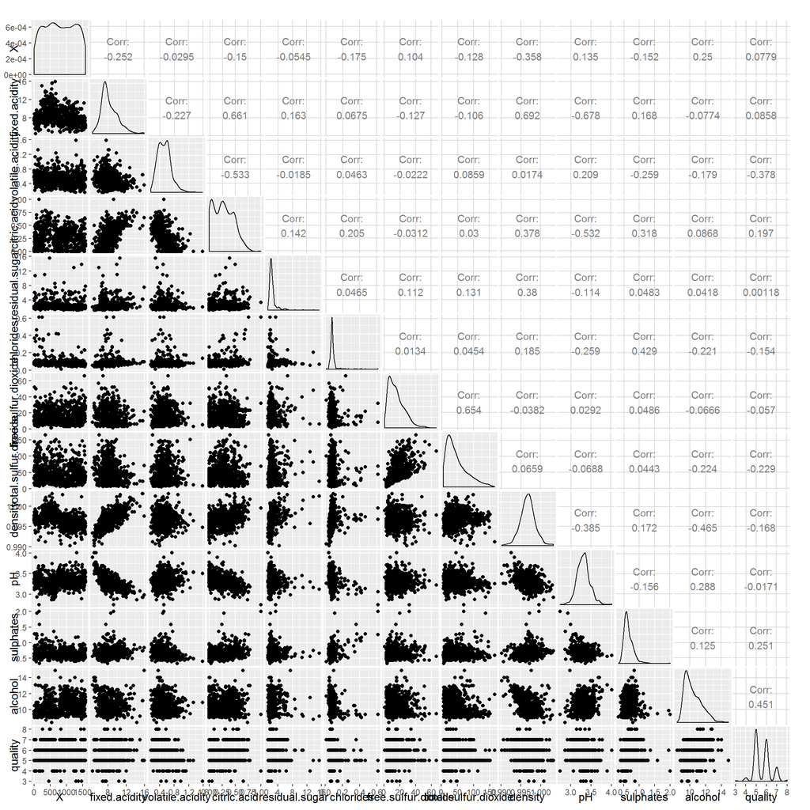

## Is there a relationship between alcohol concentration and wine quality?

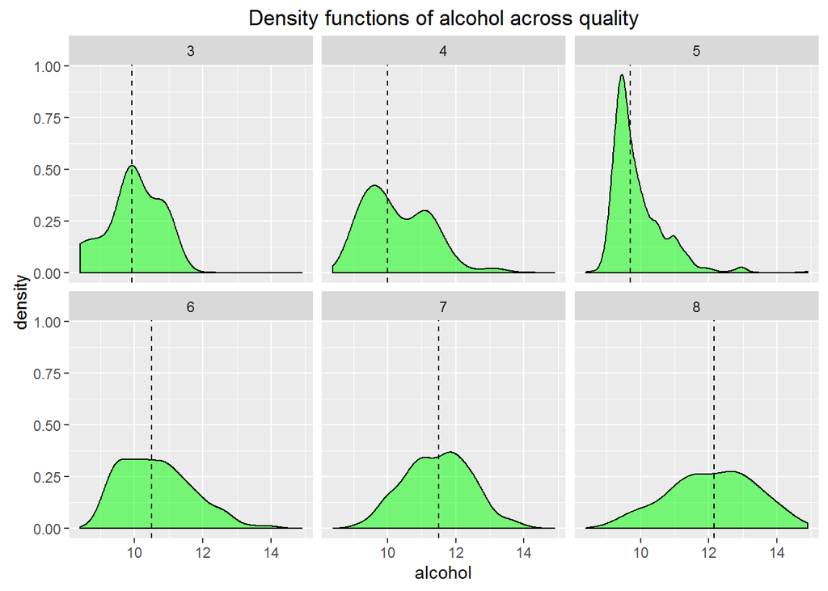

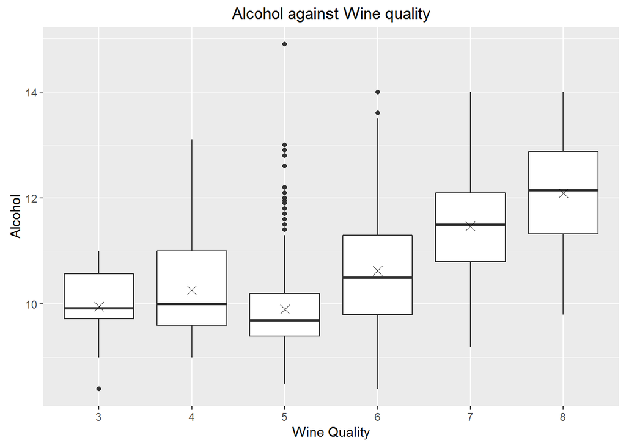

The above plots reveal that alcohol concentration is clearly related to wine quality for mediocre and high quality values(5 - 8). As the alcohol concentration increases the wine quality also increases.

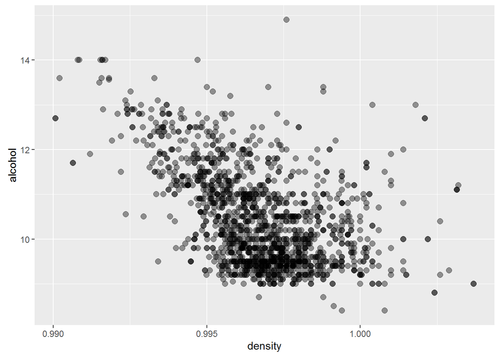

# Modeling

## Read in the data and split it into testing and training

```r
## read in the data for red wine quality
wineQuality <- read.csv("wineQualityReds.csv")
## removing the index column
wineQuality <- wineQuality[, -1]

## checking the available variables and variable types
names(wineQuality)
```

```
##  [1] "fixed.acidity"        "volatile.acidity"     "citric.acid"
##  [4] "residual.sugar"       "chlorides"            "free.sulfur.dioxide"
##  [7] "total.sulfur.dioxide" "density"              "pH"
## [10] "sulphates"            "alcohol"              "quality"
```

```r
str(wineQuality)
```

```
## 'data.frame':    1599 obs. of  12 variables:
##  $ fixed.acidity       : num  7.4 7.8 7.8 11.2 7.4 7.4 7.9 7.3 7.8 7.5 ...
##  $ volatile.acidity    : num  0.7 0.88 0.76 0.28 0.7 0.66 0.6 0.65 0.58 0.5 ...
##  $ citric.acid         : num  0 0 0.04 0.56 0 0 0.06 0 0.02 0.36 ...
##  $ residual.sugar      : num  1.9 2.6 2.3 1.9 1.9 1.8 1.6 1.2 2 6.1 ...
##  $ chlorides           : num  0.076 0.098 0.092 0.075 0.076 0.075 0.069 0.065 0.073 0.071 ...
##  $ free.sulfur.dioxide : num  11 25 15 17 11 13 15 15 9 17 ...
##  $ total.sulfur.dioxide: num  34 67 54 60 34 40 59 21 18 102 ...
##  $ density             : num  0.998 0.997 0.997 0.998 0.998 ...
##  $ pH                  : num  3.51 3.2 3.26 3.16 3.51 3.51 3.3 3.39 3.36 3.35 ...
##  $ sulphates           : num  0.56 0.68 0.65 0.58 0.56 0.56 0.46 0.47 0.57 0.8 ...
##  $ alcohol             : num  9.4 9.8 9.8 9.8 9.4 9.4 9.4 10 9.5 10.5 ...
##  $ quality             : int  5 5 5 6 5 5 5 7 7 5 ...
```

```r
## some exploratory charts here

## spliting into test and training set
set.seed(123)
train_idx <- sample(x = 1:dim(wineQuality)[1], replace = FALSE, size = 1000)
wineQuality_train <- wineQuality[train_idx, ]
wineQuality_test <- wineQuality[-train_idx, ]
```

We are taking quality of the wine as a dependent variable and we are going to use other factors to predict the quality of the red wine. The quality of the wine is assessed by the wine tasters and is based on their subjective tastes and preferences. So in a sense we are predicting human behavior. These results can be extrapolated (if all external validity questions are taken care of) to a bigger population of wine drinkers and can possibly be used to predict “preferences” and maybe even sales of the wine based on its chemical content. We are going to try and assess several models and choose the one that predicts the best.

## Simple Linear Model

```r
## starting with a simple linear model with forward selection
null_model <- lm(quality ~ 1, data = wineQuality_train)
full_model <- lm(quality ~ ., data = wineQuality_train)
fwd_sel <- step(null_model, scope = list(lower = null_model, upper = full_model), direction = "forward")
```

```
## Start:  AIC=-444.49
## quality ~ 1
##
##                        Df Sum of Sq    RSS     AIC
## + alcohol               1   153.961 485.91 -717.73
## + volatile.acidity      1   102.472 537.40 -617.01
## + sulphates             1    41.465 598.41 -509.49
## + citric.acid           1    35.839 604.03 -500.13
## + density               1    19.468 620.40 -473.39
## + total.sulfur.dioxide  1    14.106 625.77 -464.78
## + chlorides             1    10.979 628.89 -459.80
## + fixed.acidity         1     9.940 629.93 -458.15
## + pH                    1     2.352 637.52 -446.17
## <none>                              639.87 -444.49
## + residual.sugar        1     0.064 639.81 -442.59
## + free.sulfur.dioxide   1     0.058 639.81 -442.58
##
## Step:  AIC=-717.73
## quality ~ alcohol
##
##                        Df Sum of Sq    RSS     AIC
## + volatile.acidity      1    59.505 426.40 -846.37
## + sulphates             1    25.899 460.01 -770.51
## + citric.acid           1    18.652 467.26 -754.87
## + pH                    1    14.898 471.01 -746.87
## + fixed.acidity         1    13.667 472.24 -744.26
## + density               1     3.411 482.50 -722.78
## + total.sulfur.dioxide  1     2.273 483.64 -720.42
## <none>                              485.91 -717.73
## + chlorides             1     0.496 485.41 -716.75
## + free.sulfur.dioxide   1     0.292 485.62 -716.33
## + residual.sugar        1     0.264 485.65 -716.28
##
## Step:  AIC=-846.37
## quality ~ alcohol + volatile.acidity
##
##                        Df Sum of Sq    RSS     AIC
## + sulphates             1    8.8839 417.52 -865.42
## + pH                    1    2.4883 423.92 -850.22
## + fixed.acidity         1    2.4616 423.94 -850.16
```

[output cut: 55 more lines]

```
## <none>                        409.60 -878.58
## + density         1    0.1979 409.40 -877.06
## + citric.acid     1    0.1332 409.47 -876.90
## + residual.sugar  1    0.0419 409.56 -876.68
##
## Step:  AIC=-885.62
## quality ~ alcohol + volatile.acidity + sulphates + chlorides +
##     total.sulfur.dioxide + free.sulfur.dioxide + pH
##
##                  Df Sum of Sq    RSS     AIC
## <none>                        405.91 -885.62
## + citric.acid     1  0.294620 405.62 -884.35
## + residual.sugar  1  0.136604 405.78 -883.96
## + fixed.acidity   1  0.000246 405.91 -883.62
## + density         1  0.000004 405.91 -883.62
```

```r
lm_preds <- predict(fwd_sel, newdata = wineQuality_test)
lm_preds <- round(lm_preds)

lm_conf_matrix <- table(wineQuality_test$quality, lm_preds)
lm_conf_matrix
```

```
##    lm_preds
##       5   6   7
##   3   4   1   0
##   4  12   6   0
##   5 184  64   1
##   6  82 158   5
##   7   4  57  12
##   8   0   6   3
```

```r
## checking the accuracy of the model
lm_accuracy <- (lm_conf_matrix[3, 1] + lm_conf_matrix[4, 2] + lm_conf_matrix[5, 3])/ dim(wineQuality_test)[1]
lm_accuracy
```

```
## [1] 0.590985
```

In order to measure the accuracy of prediction we are rounding our predictions with the round(lm_preds) line and after that we comapre our predictions to the actual data in the testing set. If we look at the lm confusion matrix we can calcualte the accuracy of our prediction which is roughly around 60% (0.59 to be exact)

## Add polynomials to our model to increase predictability

After testing the simple linear modeal we are trying to explore the curveture of our data set and add the polynomials to the data set:

```r
polynomial_lm <- lm <- lm(formula = quality ~ alcohol + volatile.acidity + sulphates + chlorides +
                            total.sulfur.dioxide + free.sulfur.dioxide + pH + I(alcohol ^ 2) +
                            I(volatile.acidity ^ 2) + I(pH ^ 2),
                          data = wineQuality_train)

poly_preds <- predict(polynomial_lm, newdata = wineQuality_test)
poly_preds <- round(poly_preds)

poly_lm_conf_matrix <- table(wineQuality_test$quality, poly_preds)
poly_lm_conf_matrix
```

```
##    poly_preds
##       5   6   7
##   3   4   1   0
##   4  12   6   0
##   5 188  59   2
##   6  77 163   5
##   7   6  57  10
##   8   0   7   2
```

```r
## checking the accuracy of the model
poly_accuracy <- (poly_lm_conf_matrix[3, 1] + poly_lm_conf_matrix[4, 2] + poly_lm_conf_matrix[5, 3])/ dim(wineQuality_test)[1]
poly_accuracy
```

```
## [1] 0.6026711
```

We have tested several square and cubic terms on sveral variables and came to a conclusion that adding square terms to alcohol, volatile acidity and pH balance yields the best resutls. The accuracy of this prediction is slightly better than a simple linear model but is not significcnatly different. It is still 60%.

## Generalized additive model with splines

Now we want to test that if more flexibility will yield better results by lookng at different sections of for each variable and then adding them together.

```r
library(gam)
ga.model <- gam(quality ~ s(alcohol,2) + s(volatile.acidity,2) + s(sulphates,2) + s(chlorides,2) +
                  s(total.sulfur.dioxide,2) + s(free.sulfur.dioxide,2) + s(pH,2),
                data = wineQuality_train)
gam_preds <- predict(ga.model, newdata = wineQuality_test)
gam_preds <- round(gam_preds)

gam_conf_matrix <- table(wineQuality_test$quality, gam_preds)
gam_conf_matrix
```

```
##    gam_preds
##       5   6   7
##   3   4   1   0
##   4  12   6   0
##   5 192  55   2
##   6  79 162   4
##   7   4  48  21
##   8   0   7   2
```

```r
## checking the accuracy of the model
gam_accuracy <- (gam_conf_matrix[3, 1] + gam_conf_matrix[4, 2] + gam_conf_matrix[5, 3])/ dim(wineQuality_test)[1]
gam_accuracy
```

```
## [1] 0.6260434
```

Generalized additive model with splines gives us an accuracy of 62% which is a 2% increase from the previous model.

## Multinomial logistic regression

Now, let’s switch from linear continuous response methods to classification methods

```r
library(nnet)
logit <- multinom(formula = quality ~ alcohol + volatile.acidity + sulphates + chlorides +
                    total.sulfur.dioxide + free.sulfur.dioxide + pH,
                  data = wineQuality_train)
logit_preds <- predict(logit, newdata = wineQuality_test)

logit_conf_matrix <- table(wineQuality_test$quality, logit_preds)
logit_conf_matrix
```

```
##    logit_preds
##       3   4   5   6   7   8
##   3   0   0   4   1   0   0
##   4   0   0  16   2   0   0
##   5   0   0 205  43   1   0
##   6   0   0  97 132  15   1
##   7   0   0   8  40  25   0
##   8   0   0   0   7   2   0
```

```r
## checking the accuracy of the model
logit_accuracy <- sum(diag(logit_conf_matrix))/ dim(wineQuality_test)[1]
logit_accuracy
```

```
## [1] 0.6043406
```

The accuracy of this model is 60% which is less than 62% of the previous model

## Tree (Random Forest) method.

Now from the classification methods we will test the Tree model.

```r
## trying tree (random Forests) methods for classification
library(randomForest)
library(gbm)
set.seed(123)
bagging_model <- randomForest(as.factor(quality) ~ ., data = wineQuality_train, ntree = 500, mtry = 4)
bagging_pred <- predict(bagging_model, newdata = wineQuality_test)
## bagging_pred <- round(bagging_pred)
bagging_conf_matrix <- table(wineQuality_test$quality, bagging_pred)
bagging_conf_matrix
```

```
##    bagging_pred
##       3   4   5   6   7   8
##   3   0   1   4   0   0   0
##   4   0   0  13   5   0   0
##   5   0   0 216  30   3   0
##   6   0   0  63 166  16   0
##   7   0   0   4  24  45   0
##   8   0   0   0   4   4   1
```

```r
bagging_accuracy <- sum(diag(bagging_conf_matrix))/ dim(wineQuality_test)[1]
bagging_accuracy
```

```
## [1] 0.7145242
```

The random forest method reduces variance by generating a big number of trees and then averages them out.

As a result we get a result of 71% accuracy which is the highest among our methods. It is necessary to note that the wrong predictions in the above confusion matrix are mostly close to the right ones (meaning most of the predictions are around the diagonal of the confusion matrix) by a margin of one (which means that our model is not too far off the target most of the time). we are inclined to choose this method as the one which does the best prediction on our testing data.